# Introducción a **`tidyquant`**

[figure not shown]

[`tidyquant`](https://business-science.github.io/tidyquant/index.html) es una paquetería de **R** que tiene dos principales funciones:

- Ser un puente para usuarios acostumbrados a trabajar en Excel. Más información en [este blog](https://www.business-science.io/finance/2020/02/26/r-for-excel-users.html).
- Unir las paqueterías `quantmod` (para análisis financiero) y `xts` (para manejo de series de tiempo), con la estructura y funcionamiento de las paqueterías que conforman el `tidyverse`.

Para comenzar, veamos unos breves ejemplos. Lo primero que debemos hacer (después de instalar `tidyquant`) es cargar las paqueterías en el entorno.

**NOTA:** *Este documento está basado en la documentación y tutoriales que se muestran en la página de `tidyquant`*

```r
# install.packages("tidyquant") # correr solo una vez por equipo
library(tidyverse)
library(tidyquant)
library(tsibble)
library(plotly)
library(lubridate)
```

Al cargarla, se muestra información respecto a las paqueterías que está cargando y si hubiera funciones que están sustituyendo a otras previamente cargadas.

# Descarga de datos económicos / financieros

Una de las grandes ventajas de utilizar `tidyquant`, es que se puede descargar una gran cantidad de información con solo llamar unas sencillas funciones.

## Índices bursátiles

- Para descargar información respecto a **índices bursátiles**, podemo usar `tq_index()`, lo que nos mostrará la composición del índice en cuestión.

```r
tq_index("SP500")
```

```
Getting holdings for SP500
```

| symbol | company | identifier | sedol | weight | sector | shares_held | local_currency |
| --- | --- | --- | --- | --- | --- | --- | --- |
| AAPL | Apple Inc. | 03783310 | 2046251 | 6.272865e-02 | Information Technology | 163510800 | USD |
| MSFT | Microsoft Corporation | 59491810 | 2588173 | 5.577447e-02 | Information Technology | 77352350 | USD |
| AMZN | Amazon.com Inc. | 02313510 | 2000019 | 4.295269e-02 | Consumer Discretionary | 4363460 | USD |
| FB | Facebook Inc. Class A | 30303M10 | B7TL820 | 1.959658e-02 | Communication Services | 24595340 | USD |
| GOOGL | Alphabet Inc. Class A | 02079K30 | BYVY8G0 | 1.915749e-02 | Communication Services | 3075909 | USD |
| GOOG | Alphabet Inc. Class C | 02079K10 | BYY88Y7 | 1.859740e-02 | Communication Services | 2969917 | USD |
| TSLA | Tesla Inc | 88160R10 | B616C79 | 1.806775e-02 | Consumer Discretionary | 7758426 | USD |
| BRK.B | Berkshire Hathaway Inc. Class B | 08467070 | 2073390 | 1.433963e-02 | Financials | 19911000 | USD |
| JPM | JPMorgan Chase & Co. | 46625H10 | 2190385 | 1.342905e-02 | Financials | 31186566 | USD |
| JNJ | Johnson & Johnson | 47816010 | 2475833 | 1.320297e-02 | Health Care | 26933848 | USD |

[output cut: 495 more lines]

**NOTA:** Para saber qué opciones tenemos, podemos utilizar `tq_index_options()`:

```r
tq_index_options()
```

```
[1] "DOW"       "DOWGLOBAL" "SP400"     "SP500"
[5] "SP600"
```

## Bolsas de valores

- Para obtener información respecto a **bolsas de valores**, podemos utilizar la función `tq_exchange()`. Similarmente, para ver las opciones que existen, podemos utilizar `tq_exchange_options()`.

```r
tq_exchange_options()
```

```
[1] "AMEX"   "NASDAQ" "NYSE"
```

```r
tq_exchange("NASDAQ")
```

[output not shown]

## Datos cuantitativos

La función `tq_get()` puede descargarnos una gran cantidad de información. Dentro de está función se especifica cuáles datos queremos en el argumento `get =`. Las fuentes de donde se pueden obtener datos son:

1. [**Yahoo Finance**](https://finance.yahoo.com/) - para datos diarios de acciones.
2. [**FRED**](https://fred.stlouisfed.org/) - (Reserva federal de datos económicos de St. Louis) para datos económicos.
3. [**Quandl**](https://www.quandl.com/) - API para obtener datos económicos, financieros y de energía.
4. [**Tiingo**](https://www.tiingo.com/) - API para datos financieros intradía y de criptomonedas.
5. [**Alpha Vantage**](https://www.alphavantage.co/) - API para datos financieros intradía, ForEx y criptomonedas.
6. [**Bloomberg**](https://www.bloomberg.com/) - Una de las APIs financieras más utilizadas en el mundo. Se requiere una cuenta de paga.

Vemos las diferentes opciones que tenemos con esta función con `tq_get_options()`.

```r
tq_get_options()
```

```
 [1] "stock.prices"       "stock.prices.japan"
 [3] "dividends"          "splits"
 [5] "economic.data"      "quandl"
 [7] "quandl.datatable"   "tiingo"
 [9] "tiingo.iex"         "tiingo.crypto"
[11] "alphavantager"      "alphavantage"
[13] "rblpapi"
```

### Precio de acciones

Especificando el argumento `get = "stock.prices"`, podemos descargar el **precio de una o más acciones** simultáneamente. Si se quiere definir un periodo de tiempo, se agregan los argumentos `from =` y `to =`.

```r
(tesla <- tq_get("TSLA", get = "stock.prices", from = "2019-01-01", to = "2021-02-18"))
```

| symbol | date | open | high | low | close | volume | adjusted |
| --- | --- | --- | --- | --- | --- | --- | --- |
| TSLA | 2019-01-02 | 61.220 | 63.026 | 59.760 | 62.024 | 58293000 | 62.024 |
| TSLA | 2019-01-03 | 61.400 | 61.880 | 59.476 | 60.072 | 34826000 | 60.072 |
| TSLA | 2019-01-04 | 61.200 | 63.600 | 60.546 | 63.538 | 36970500 | 63.538 |
| TSLA | 2019-01-07 | 64.344 | 67.348 | 63.550 | 66.992 | 37756000 | 66.992 |
| TSLA | 2019-01-08 | 68.392 | 68.802 | 65.404 | 67.070 | 35042500 | 67.070 |
| TSLA | 2019-01-09 | 67.100 | 68.700 | 66.294 | 67.706 | 27164500 | 67.706 |
| TSLA | 2019-01-10 | 66.880 | 69.078 | 66.358 | 68.994 | 30282000 | 68.994 |
| TSLA | 2019-01-11 | 68.418 | 69.682 | 67.754 | 69.452 | 25195500 | 69.452 |
| TSLA | 2019-01-14 | 68.476 | 68.500 | 66.800 | 66.880 | 26236500 | 66.880 |
| TSLA | 2019-01-15 | 67.000 | 69.760 | 66.900 | 68.886 | 30283000 | 68.886 |

[output cut: 526 more lines]

Para descargar simultáneamente los precios de todas las acciones que componen el S&P500 desde 2020 a la fecha, lo podríamos hacer como se muestra debajo.

```r
sp500 <- tq_index("SP500") %>%
  tq_get(get = "stock.prices", from = "2020-05-01")
```

[output not shown]

```r
sp500
```

| symbol | company | identifier | sedol | weight | sector | shares_held | local_currency | date | open | high | low | close | volume | adjusted |
| --- | --- | --- | --- | --- | --- | --- | --- | --- | --- | --- | --- | --- | --- | --- |
| AAPL | Apple Inc. | 03783310 | 2046251 | 0.06272865 | Information Technology | 163510800 | USD | 2020-05-01 | 71.5625 | 74.7500 | 71.4625 | 72.2675 | 240616800 | 71.71163 |
| AAPL | Apple Inc. | 03783310 | 2046251 | 0.06272865 | Information Technology | 163510800 | USD | 2020-05-04 | 72.2925 | 73.4225 | 71.5800 | 73.2900 | 133568000 | 72.72626 |
| AAPL | Apple Inc. | 03783310 | 2046251 | 0.06272865 | Information Technology | 163510800 | USD | 2020-05-05 | 73.7650 | 75.2500 | 73.6150 | 74.3900 | 147751200 | 73.81780 |
| AAPL | Apple Inc. | 03783310 | 2046251 | 0.06272865 | Information Technology | 163510800 | USD | 2020-05-06 | 75.1150 | 75.8100 | 74.7175 | 75.1575 | 142333600 | 74.57939 |
| AAPL | Apple Inc. | 03783310 | 2046251 | 0.06272865 | Information Technology | 163510800 | USD | 2020-05-07 | 75.8050 | 76.2925 | 75.4925 | 75.9350 | 115215200 | 75.35091 |
| AAPL | Apple Inc. | 03783310 | 2046251 | 0.06272865 | Information Technology | 163510800 | USD | 2020-05-08 | 76.4100 | 77.5875 | 76.0725 | 77.5325 | 134048000 | 77.14439 |
| AAPL | Apple Inc. | 03783310 | 2046251 | 0.06272865 | Information Technology | 163510800 | USD | 2020-05-11 | 77.0250 | 79.2625 | 76.8100 | 78.7525 | 145946400 | 78.35828 |
| AAPL | Apple Inc. | 03783310 | 2046251 | 0.06272865 | Information Technology | 163510800 | USD | 2020-05-12 | 79.4575 | 79.9225 | 77.7275 | 77.8525 | 162301200 | 77.46279 |
| AAPL | Apple Inc. | 03783310 | 2046251 | 0.06272865 | Information Technology | 163510800 | USD | 2020-05-13 | 78.0375 | 78.9875 | 75.8025 | 76.9125 | 200622400 | 76.52750 |
| AAPL | Apple Inc. | 03783310 | 2046251 | 0.06272865 | Information Technology | 163510800 | USD | 2020-05-14 | 76.1275 | 77.4475 | 75.3825 | 77.3850 | 158929200 | 76.99764 |

[output cut: 990 more lines]

De manera similar, se pueden obtener los datos de las acciones en particular que se deseen. P. ej., si se quiere obtener el precio de Microsoft (MSFT), Apple (AAPL), Johnson & Johnson (JNJ), Visa (V), podemos hacer lo siguiente:

```r
c("MSFT","AAPL","JNJ","V") %>%
  tq_get(get = "stock.prices",
         from = "1980-01-01",
         to = "2020-09-15")
```

| symbol | date | open | high | low | close | volume | adjusted |
| --- | --- | --- | --- | --- | --- | --- | --- |
| MSFT | 1986-03-13 | 0.088542 | 0.101563 | 0.088542 | 0.097222 | 1031788800 | 0.061751 |
| MSFT | 1986-03-14 | 0.097222 | 0.102431 | 0.097222 | 0.100694 | 308160000 | 0.063956 |
| MSFT | 1986-03-17 | 0.100694 | 0.103299 | 0.100694 | 0.102431 | 133171200 | 0.065059 |
| MSFT | 1986-03-18 | 0.102431 | 0.103299 | 0.098958 | 0.099826 | 67766400 | 0.063405 |
| MSFT | 1986-03-19 | 0.099826 | 0.100694 | 0.097222 | 0.098090 | 47894400 | 0.062302 |
| MSFT | 1986-03-20 | 0.098090 | 0.098090 | 0.094618 | 0.095486 | 58435200 | 0.060648 |
| MSFT | 1986-03-21 | 0.095486 | 0.097222 | 0.091146 | 0.092882 | 59990400 | 0.058994 |
| MSFT | 1986-03-24 | 0.092882 | 0.092882 | 0.089410 | 0.090278 | 65289600 | 0.057340 |
| MSFT | 1986-03-25 | 0.090278 | 0.092014 | 0.089410 | 0.092014 | 32083200 | 0.058443 |
| MSFT | 1986-03-26 | 0.092014 | 0.095486 | 0.091146 | 0.094618 | 22752000 | 0.060097 |

[output cut: 990 more lines]

### Datos económicos

Los datos económicos de la reserva federal del banco de St. Louis (o FRED, para resumirlo) posee más de 765,000 series de tiempo de EEUU e internacionales, de 96 fuentes distintas, que se pueden descargar directamente desde **R**. Para esto, es necesario conocer el código de la serie (que se puede encontrar en la página web del FRED). Descarguemos, por ejemplo, las ventas mensuales totales de autos en EEUU. La serie se llama `TOTALNSA` y descargaremos datos a partir de enero de 1980.

```r
car_sales <- tq_get("TOTALNSA",
                    get = "economic.data",
                    from = "1980-01-01")
car_sales
```

| symbol | date | price |
| --- | --- | --- |
| TOTALNSA | 1980-01-01 | 1042.000 |
| TOTALNSA | 1980-02-01 | 1038.700 |
| TOTALNSA | 1980-03-01 | 1141.900 |
| TOTALNSA | 1980-04-01 | 946.600 |
| TOTALNSA | 1980-05-01 | 893.800 |
| TOTALNSA | 1980-06-01 | 932.700 |
| TOTALNSA | 1980-07-01 | 1006.600 |
| TOTALNSA | 1980-08-01 | 884.200 |
| TOTALNSA | 1980-09-01 | 847.400 |
| TOTALNSA | 1980-10-01 | 1043.400 |

[output cut: 483 more lines]

Para ver cómo sería la consulta de las otras fuentes de información, se puede consultar fácilmente la documentación de la paquetería o dar clic [aquí](https://business-science.github.io/tidyquant/articles/TQ01-core-functions-in-tidyquant.html#fred-economic-data),

# Transformaciones de datos cuantitativos

Muchas de las transformaciones que normalmente se utilizan en el análisis financiero se pueden realizar directamente con `tidyquant`. Por simplicidad, utilizaremos la tabla `FANG` que contiene precios de las acciones de Facebook, Amazon, Netflix y Google de 2013 a 2016.

```r
FANG
```

| symbol | date | open | high | low | close | volume | adjusted |
| --- | --- | --- | --- | --- | --- | --- | --- |
| FB | 2013-01-02 | 27.44 | 28.18 | 27.42 | 28.00 | 69846400 | 28.00 |
| FB | 2013-01-03 | 27.88 | 28.47 | 27.59 | 27.77 | 63140600 | 27.77 |
| FB | 2013-01-04 | 28.01 | 28.93 | 27.83 | 28.76 | 72715400 | 28.76 |
| FB | 2013-01-07 | 28.69 | 29.79 | 28.65 | 29.42 | 83781800 | 29.42 |
| FB | 2013-01-08 | 29.51 | 29.60 | 28.86 | 29.06 | 45871300 | 29.06 |
| FB | 2013-01-09 | 29.67 | 30.60 | 29.49 | 30.59 | 104787700 | 30.59 |
| FB | 2013-01-10 | 30.60 | 31.45 | 30.28 | 31.30 | 95316400 | 31.30 |
| FB | 2013-01-11 | 31.28 | 31.96 | 31.10 | 31.72 | 89598000 | 31.72 |
| FB | 2013-01-14 | 32.08 | 32.21 | 30.62 | 30.95 | 98892800 | 30.95 |
| FB | 2013-01-15 | 30.64 | 31.71 | 29.88 | 30.10 | 173242600 | 30.10 |

[output cut: 990 more lines]

Podemos agregar los datos ajustados de diarios a mensuales, especificando el argumento `mutate_fun = to.monthly`:

```r
FANG %>%
  group_by(symbol) %>%
  tq_transmute(select = adjusted,
               mutate_fun = to.monthly,
               indexAt = "lastof")
```

| symbol | date | adjusted |
| --- | --- | --- |
| FB | 2013-01-31 | 30.98000 |
| FB | 2013-02-28 | 27.25000 |
| FB | 2013-03-31 | 25.58000 |
| FB | 2013-04-30 | 27.77000 |
| FB | 2013-05-31 | 24.35000 |
| FB | 2013-06-30 | 24.88000 |
| FB | 2013-07-31 | 36.80000 |
| FB | 2013-08-31 | 41.29000 |
| FB | 2013-09-30 | 50.23000 |
| FB | 2013-10-31 | 50.21000 |

[output cut: 182 more lines]

```r
tq_mutate_fun_options()
```

```
$zoo
 [1] "rollapply"          "rollapplyr"
 [3] "rollmax"            "rollmax.default"
 [5] "rollmaxr"           "rollmean"
 [7] "rollmean.default"   "rollmeanr"
 [9] "rollmedian"         "rollmedian.default"
[11] "rollmedianr"        "rollsum"
[13] "rollsum.default"    "rollsumr"

$xts
 [1] "apply.daily"     "apply.monthly"
 [3] "apply.quarterly" "apply.weekly"
 [5] "apply.yearly"    "diff.xts"
 [7] "lag.xts"         "period.apply"
 [9] "period.max"      "period.min"
```

[output cut: 67 more lines]

Si se quisiera calcular los **rendimientos mensuales** de las acciones, utilizaríamos `mutate_fun = monthlyReturn`:

```r
FANG %>%
  group_by(symbol) %>%
  tq_transmute(select = adjusted,
               mutate_fun = monthlyReturn)
```

| symbol | date | monthly.returns |
| --- | --- | --- |
| FB | 2013-01-31 | 0.1064285714 |
| FB | 2013-02-28 | -0.1204002582 |
| FB | 2013-03-28 | -0.0612844037 |
| FB | 2013-04-30 | 0.0856137608 |
| FB | 2013-05-31 | -0.1231544833 |
| FB | 2013-06-28 | 0.0217658727 |
| FB | 2013-07-31 | 0.4790996977 |
| FB | 2013-08-30 | 0.1220109272 |
| FB | 2013-09-30 | 0.2165172871 |
| FB | 2013-10-31 | -0.0003981883 |

[output cut: 182 more lines]

Se pueden calcular fácilmente indicadores de análisis técnico, como el MACD (Moving Average Convergence Divergence) y la señal:

```r
FANG %>%
    group_by(symbol) %>%
    tq_mutate(select     = close,
              mutate_fun = MACD,
              col_rename = c("MACD", "Signal"))
```

| symbol | date | open | high | low | close | volume | adjusted | MACD | Signal |
| --- | --- | --- | --- | --- | --- | --- | --- | --- | --- |
| FB | 2013-01-02 | 27.44 | 28.18 | 27.42 | 28.00 | 69846400 | 28.00 | NA | NA |
| FB | 2013-01-03 | 27.88 | 28.47 | 27.59 | 27.77 | 63140600 | 27.77 | NA | NA |
| FB | 2013-01-04 | 28.01 | 28.93 | 27.83 | 28.76 | 72715400 | 28.76 | NA | NA |
| FB | 2013-01-07 | 28.69 | 29.79 | 28.65 | 29.42 | 83781800 | 29.42 | NA | NA |
| FB | 2013-01-08 | 29.51 | 29.60 | 28.86 | 29.06 | 45871300 | 29.06 | NA | NA |
| FB | 2013-01-09 | 29.67 | 30.60 | 29.49 | 30.59 | 104787700 | 30.59 | NA | NA |
| FB | 2013-01-10 | 30.60 | 31.45 | 30.28 | 31.30 | 95316400 | 31.30 | NA | NA |
| FB | 2013-01-11 | 31.28 | 31.96 | 31.10 | 31.72 | 89598000 | 31.72 | NA | NA |
| FB | 2013-01-14 | 32.08 | 32.21 | 30.62 | 30.95 | 98892800 | 30.95 | NA | NA |
| FB | 2013-01-15 | 30.64 | 31.71 | 29.88 | 30.10 | 173242600 | 30.10 | NA | NA |

[output cut: 990 more lines]

## Ejemplo: convertir los precios a rendimientos

### Rendimientos anuales

Seguiremos utilizando la tabla `FANG` para este ejemplo. Para poder convertir los datos podemos usar `tq_transmute()`, junto con la función `periodReturn` para obtener los rendimientos anuales aritméticos.

```r
FANG_annual_returns <- FANG %>%
    group_by(symbol) %>%
    tq_transmute(select     = adjusted,
                 mutate_fun = periodReturn,
                 period     = "yearly",
                 type       = "arithmetic")
FANG_annual_returns
```

| symbol | date | yearly.returns |
| --- | --- | --- |
| FB | 2013-12-31 | 0.95178579 |
| FB | 2014-12-31 | 0.42763027 |
| FB | 2015-12-31 | 0.34145101 |
| FB | 2016-12-30 | 0.09927383 |
| AMZN | 2013-12-31 | 0.54984265 |
| AMZN | 2014-12-31 | -0.22177086 |
| AMZN | 2015-12-31 | 1.17783149 |
| AMZN | 2016-12-30 | 0.10945565 |
| NFLX | 2013-12-31 | 3.00141286 |
| NFLX | 2014-12-31 | -0.07214057 |

[output cut: 6 more lines]

Utilizando `ggplot2`, podemos graficar esto fácilmente:

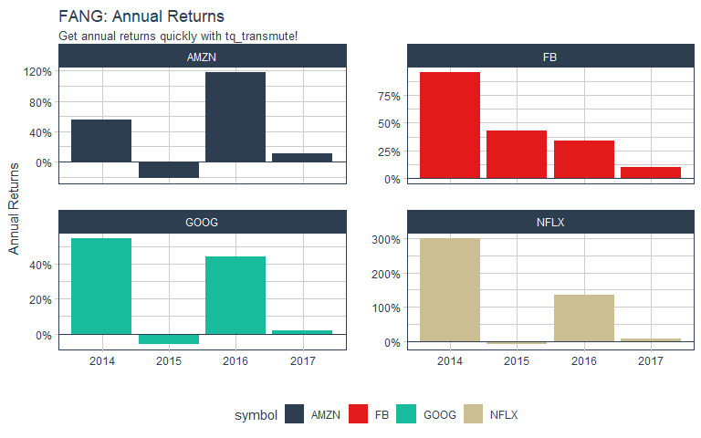

```r
FANG_annual_returns %>%
    ggplot(aes(x = date, y = yearly.returns, fill = symbol)) +
    geom_col() +
    geom_hline(yintercept = 0, color = palette_light()[[1]]) +
    scale_y_continuous(labels = scales::percent) +
    labs(title = "FANG: Annual Returns",
         subtitle = "Get annual returns quickly with tq_transmute!",
         y = "Annual Returns", x = "") +
    facet_wrap(~ symbol, ncol = 2, scales = "free_y") +
    theme_tq() +
    scale_fill_tq()
```

### Rendimientos logarítmicos diarios

```r
FANG_daily_log_returns <- FANG %>%
    group_by(symbol) %>%
    tq_transmute(select     = adjusted,
                 mutate_fun = periodReturn,
                 period     = "daily",
                 type       = "log",
                 col_rename = "daily.returns")
FANG_daily_log_returns
```

| symbol | date | daily.returns |
| --- | --- | --- |
| FB | 2013-01-02 | 0.000000e+00 |
| FB | 2013-01-03 | -8.248209e-03 |
| FB | 2013-01-04 | 3.502923e-02 |
| FB | 2013-01-07 | 2.268918e-02 |
| FB | 2013-01-08 | -1.231209e-02 |
| FB | 2013-01-09 | 5.131053e-02 |
| FB | 2013-01-10 | 2.294491e-02 |
| FB | 2013-01-11 | 1.332930e-02 |
| FB | 2013-01-14 | -2.457433e-02 |
| FB | 2013-01-15 | -2.784786e-02 |

[output cut: 990 more lines]

La gráfica:

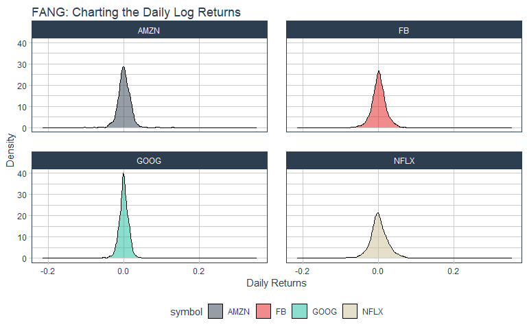

```r
FANG_daily_log_returns %>%
    ggplot(aes(x = daily.returns, fill = symbol)) +
    geom_density(alpha = 0.5) +
    labs(title = "FANG: Charting the Daily Log Returns",
         x = "Daily Returns", y = "Density") +
    theme_tq() +
    scale_fill_tq() +
    facet_wrap(~ symbol, ncol = 2)
```

# Gráficas financieras

A continuación se presentan varios tipos de gráficas que son útiles en el análisis financiero. Para agregar un tema específico de `tidyquant`, se puede agregar la capa `theme_tq()` a los `ggplot`s.

Utilizaremos los siguientes datos para graficar:

```r
AAPL <- tq_get("AAPL", get = "stock.prices", from = "2015-09-01", to = "2016-12-31")
AMZN <- tq_get("AMZN", get = "stock.prices", from = "2000-01-01", to = "2016-12-31")
```

Más adelante haremos “zoom” a algunas gráficas, por lo que aquí definiremos el inicio y fin del periodo de zoom:

```r
end <- ymd("2016-12-31")
start <- end - weeks(6)
```

### Gráfica de líneas

La tradicional, no hay mucho que decir.

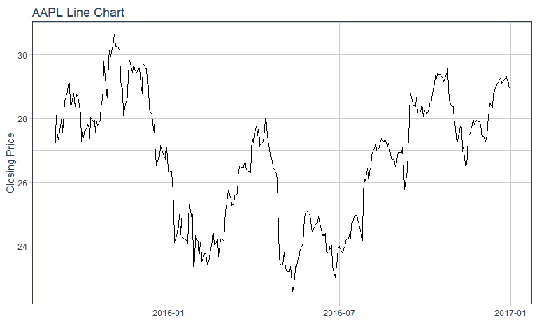

```r
AAPL %>%
    ggplot(aes(x = date, y = close)) +
    geom_line() +
    labs(title = "AAPL Line Chart", y = "Closing Price", x = "") +
    theme_tq()
```

### Bar chart

Es similar a la de líneas, pero aquí especificamos precios de apertura, cierre, máximo y mínimo y reemplazamos `geom_line()` por `geom_barchart()`

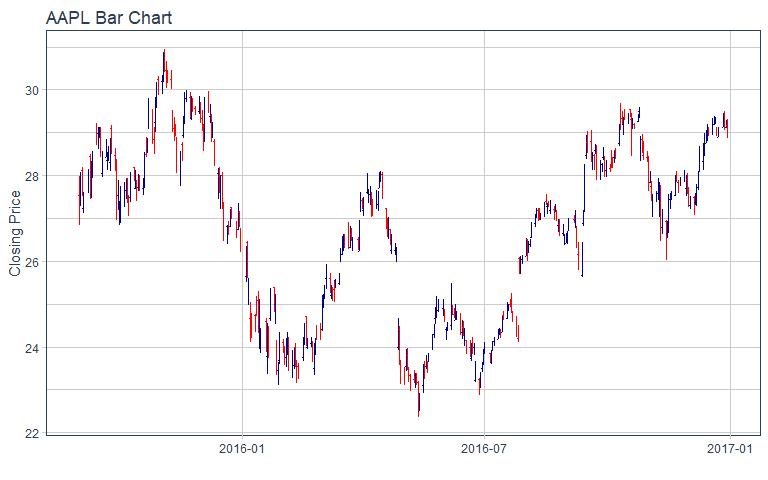

```r
apple_bar <- AAPL %>%
    ggplot(aes(x = date)) +
    geom_barchart(aes(open = open, high = high, low = low, close = close)) +
    labs(title = "AAPL Bar Chart", y = "Closing Price", x = "") +
    theme_tq()

apple_bar
```

Podemos hacer zoom a la gráfica agregando `coord_x_date()`

```r
start
```

```
[1] "2016-11-19"
```

```r
end
```

```
[1] "2016-12-31"
```

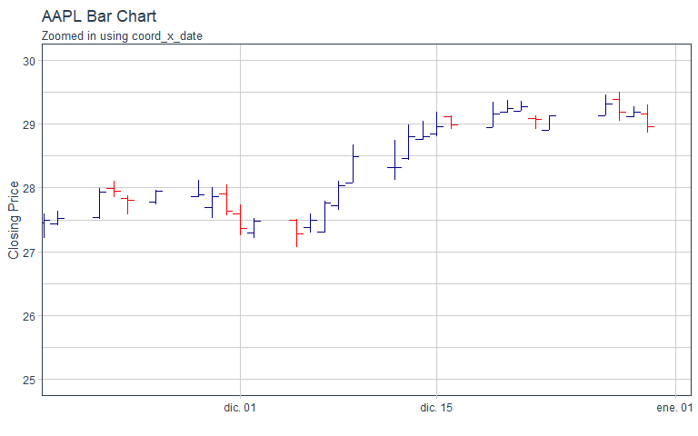

```r
AAPL %>%
    ggplot(aes(x = date, y = close)) +
    geom_barchart(aes(open = open, high = high, low = low, close = close)) +
    labs(title = "AAPL Bar Chart",
         subtitle = "Zoomed in using coord_x_date",
         y = "Closing Price", x = "") +
    coord_x_date(xlim = c(start, end),
                 ylim = c(25, 30)
                 ) +
    theme_tq()
```

Se pueden cambiar los colores con `colour_up` y `colour_down`, así como el tamaño.

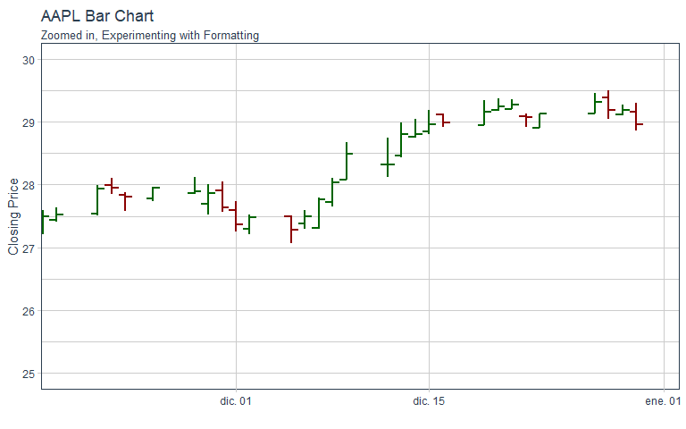

```r
AAPL %>%
    ggplot(aes(x = date, y = close)) +
    geom_barchart(aes(open = open, high = high, low = low, close = close),
                  colour_up = "darkgreen",
                  colour_down = "darkred", size = 1) +
    labs(title = "AAPL Bar Chart",
         subtitle = "Zoomed in, Experimenting with Formatting",
         y = "Closing Price", x = "") +
    coord_x_date(xlim = c(start, end),
                 ylim = c(25, 30)) +
    theme_tq()
```

### Gráfica de velas (*candlestick*)

El `geom` para este tipo de gráficos es simplemente `geom_candlestick()`

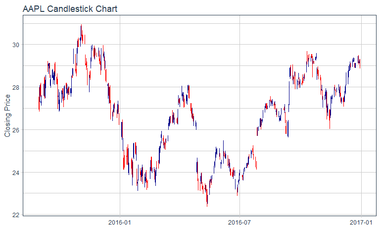

```r
AAPL %>%
    ggplot(aes(x = date, y = close)) +
    geom_candlestick(aes(open = open, high = high, low = low, close = close)) +
    labs(title = "AAPL Candlestick Chart", y = "Closing Price", x = "" ) +
    theme_tq()
```

De igual manera, podemos hacer zoom a la gráfica para ver algún periodo con mayor detalle:

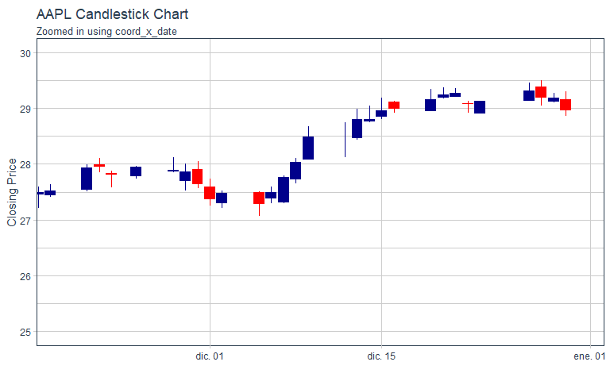

```r
AAPL %>%
    ggplot(aes(x = date, y = close)) +
    geom_candlestick(aes(open = open, high = high, low = low, close = close)) +
    labs(title = "AAPL Candlestick Chart",
         subtitle = "Zoomed in using coord_x_date",
         y = "Closing Price", x = "") +
    coord_x_date(xlim =  c(start, end),
                 ylim = c(25, 30)) +
    theme_tq()
```

Aquí se pueden cambiar el color de cuatro cosas: las líneas hacia arriba (`colour_up`), líneas hacia abajo (`colour_down`), los rectángulos (`fill_up` y `fill_down`).

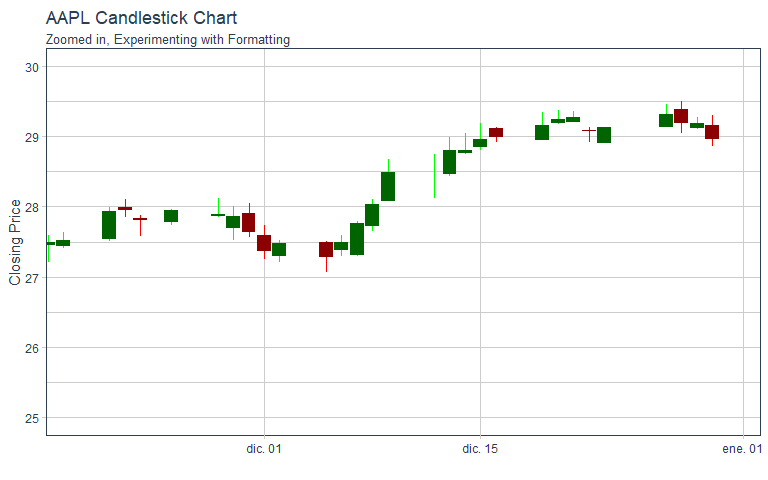

```r
AAPL %>%
    ggplot(aes(x = date, y = close)) +
    geom_candlestick(aes(open = open, high = high, low = low, close = close),
                     colour_up = "green",
                     colour_down = "red",
                     fill_up  = "darkgreen",
                     fill_down  = "darkred") +
    labs(title = "AAPL Candlestick Chart",
         subtitle = "Zoomed in, Experimenting with Formatting",
         y = "Closing Price", x = "") +
    coord_x_date(xlim = c(start, end),
                 ylim = c(25, 30)) +
    theme_tq()
```

### Graficar varios activos

Grafiquemos entonces las acciones contenidas en `FANG`, utilizando `facet_wrap()` para separarlas en un subgráfico.

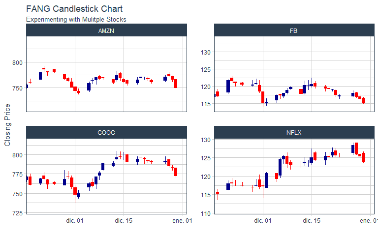

```r
FANG %>%
    filter(date >= start - days(2 * 15)) %>%
    ggplot(aes(x = date, y = close, group = symbol)) +
    geom_candlestick(aes(open = open, high = high, low = low, close = close)) +
    labs(title = "FANG Candlestick Chart",
         subtitle = "Experimenting with Mulitple Stocks",
         y = "Closing Price", x = "") +
    coord_x_date(xlim = c(start, end)) +
    facet_wrap(~ symbol, ncol = 2, scale = "free_y") +
    theme_tq()
```

# Visualizar tendencias

## Medias móviles

Las medias móviles son básicas para el análisis de series de tiempo. `tidyquant` tiene varios tipos de medias móviles ya precargados, que podemos graficar de manera muy sencilla.

### Medias móviles simples de 50 y 200 días

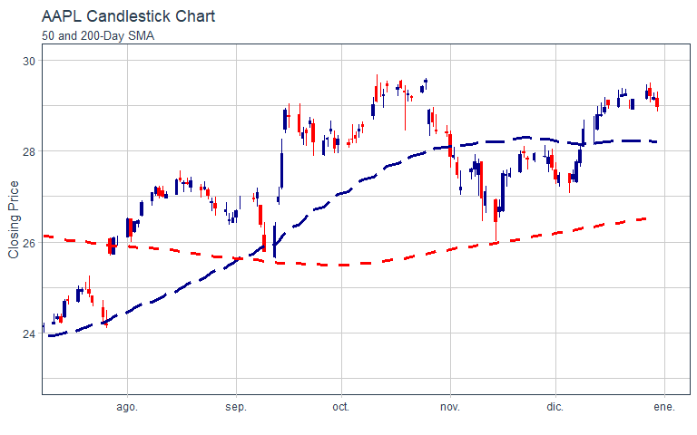

```r
AAPL %>%
    ggplot(aes(x = date, y = close)) +
    geom_candlestick(aes(open = open, high = high, low = low, close = close)) +
    geom_ma(ma_fun = SMA, n = 50, linetype = 5, size = 1.25) +
    geom_ma(ma_fun = SMA, n = 200, color = "red", size = 1.25) +
    labs(title = "AAPL Candlestick Chart",
         subtitle = "50 and 200-Day SMA",
         y = "Closing Price", x = "") +
    coord_x_date(xlim = c(end - weeks(24), end),
                 ylim = c(23, 30)) +
    theme_tq()
```

### Medias móviles para varios activos

Igual que antes, se pueden graficar varias acciones simultáneamente, utilizando facetas.

Ahora aplicaremos un *Volume-weighted average (VWMA)* para las acciones en ``FANG`.

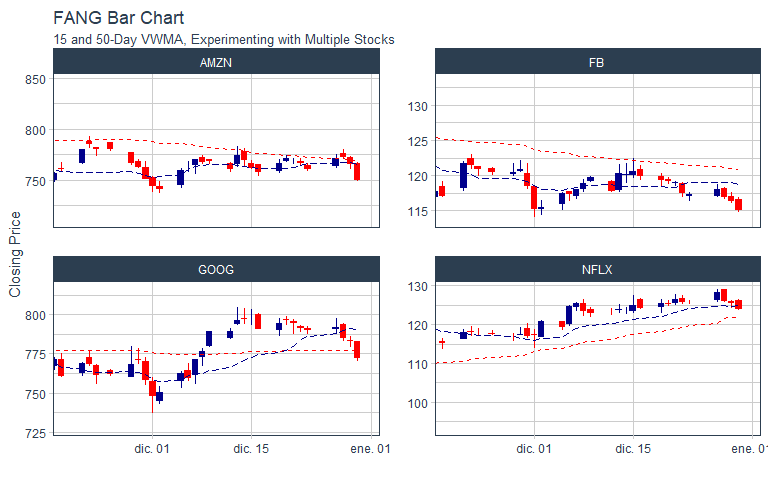

```r
start <- end - weeks(6)
FANG %>%
    filter(date >= start - days(2 * 50)) %>%
    ggplot(aes(x = date, y = close, volume = volume, group = symbol)) +
    geom_candlestick(aes(open = open, high = high, low = low, close = close)) +
    geom_ma(ma_fun = VWMA, n = 15, wilder = TRUE, linetype = 5) +
    geom_ma(ma_fun = VWMA, n = 50, wilder = TRUE, color = "red") +
    labs(title = "FANG Bar Chart",
         subtitle = "15 and 50-Day VWMA, Experimenting with Multiple Stocks",
         y = "Closing Price", x = "") +
    coord_x_date(xlim = c(start, end)) +
    facet_wrap(~ symbol, ncol = 2, scales = "free_y") +
    theme_tq()
```

## Bandas de Bollinger

Las bandas de Bollinger se usan para graficar la volatilidad de activos financieros. En **R** se pueden graficar fácilmente con `geom_bbands()`

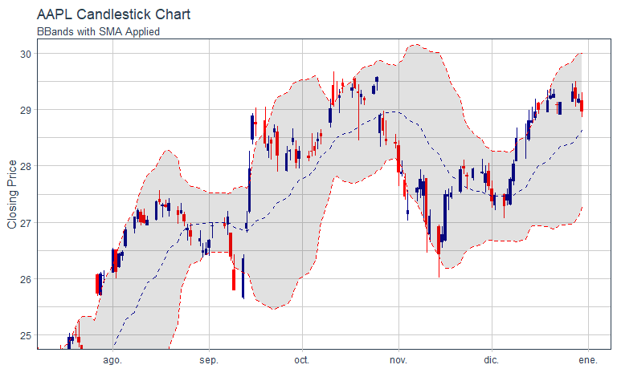

```r
AAPL %>%
    ggplot(aes(x = date, y = close, open = open,
               high = high, low = low, close = close)) +
    geom_candlestick() +
    geom_bbands(ma_fun = SMA, sd = 2, n = 20) +
    labs(title = "AAPL Candlestick Chart",
         subtitle = "BBands with SMA Applied",
         y = "Closing Price", x = "") +
    coord_x_date(xlim = c(end - weeks(24), end),
                 ylim = c(25, 30)) +
    theme_tq()
```

De manera similar a las gráficas anteriores, podemos graficar las bandas de bollinger para varias acciones simultáneamente.

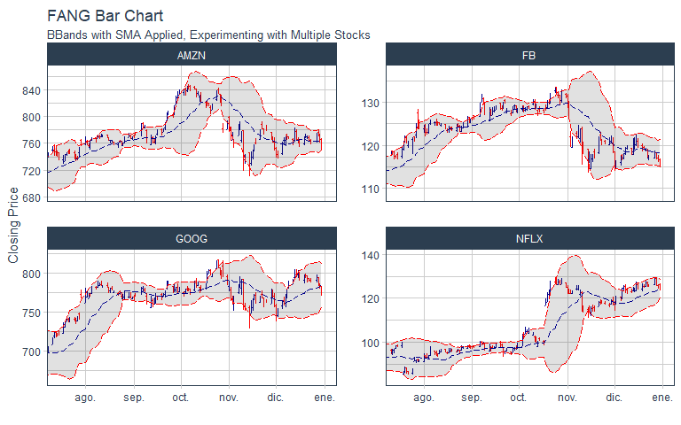

```r
start <- end - weeks(24)
FANG %>%
    filter(date >= start - days(2 * 20)) %>%
    ggplot(aes(x = date, y = close,
               open = open, high = high, low = low, close = close,
               group = symbol)) +
    geom_barchart() +
    geom_bbands(ma_fun = SMA, sd = 2, n = 20, linetype = 5) +
    labs(title = "FANG Bar Chart",
         subtitle = "BBands with SMA Applied, Experimenting with Multiple Stocks",
         y = "Closing Price", x = "") +
    coord_x_date(xlim = c(start, end)) +
    facet_wrap(~ symbol, ncol = 2, scales = "free_y") +
    theme_tq()
```

## Temas

Se pueden definir temas para modificar rápidamente el aspecto visual de sus gráficas:

- **Light:** `theme_tq() + scale_color_tq() + scale_fill_tq()`
- **Dark:** `theme_tq_dark() + scale_color_tq(theme = "dark") + scale_fill_tq(theme = "dark")`
- **Green:** `theme_tq_green() + scale_color_tq(theme = "green") + scale_fill_tq(theme = "green")`

Veamos un ejemplo con el tema oscuro:

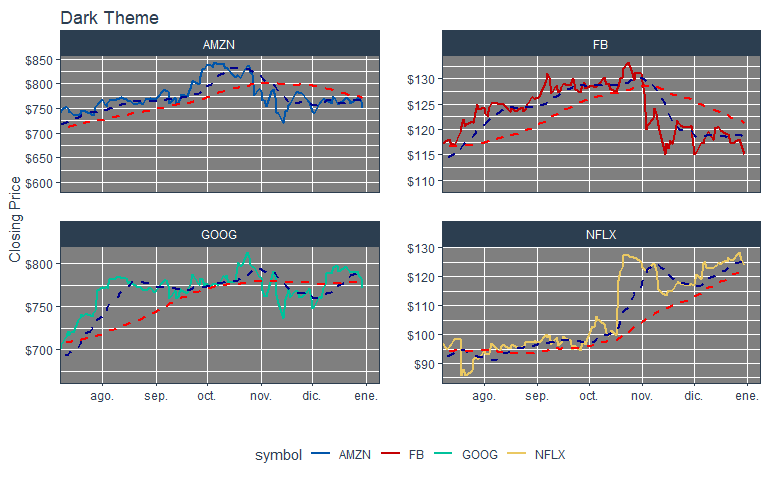

```r
n_mavg <- 50 # Number of periods (days) for moving average
FANG %>%
    filter(date >= start - days(2 * n_mavg)) %>%
    ggplot(aes(x = date, y = close, color = symbol)) +
    geom_line(size = 1) +
    geom_ma(n = 15, color = "darkblue", size = 1) +
    geom_ma(n = n_mavg, color = "red", size = 1) +
    labs(title = "Dark Theme",
         x = "", y = "Closing Price") +
    coord_x_date(xlim = c(start, end)) +
    facet_wrap(~ symbol, scales = "free_y") +
    theme_tq_dark() +
    scale_color_tq(theme = "dark") +
    scale_y_continuous(labels = scales::dollar)
```

# Performance Analysis

El análisis del desempeño de activos financieros es un tema bastante amplio, y que no es objeto de este curso. Sin embargo, en la documentación de [`tidyquant`](https://business-science.github.io/tidyquant/articles/TQ05-performance-analysis-with-tidyquant.html) vienen varios ejemplos de algunas metodologías que podrían llegar a aplicar.